# Box plot and time series combo

Since people were curious, I needed to write down how I did it, and I appreciated an excuse to mess with R Markdown, the gist of how I overlayed individual time series onto group box plots is below. The `.rmd` file is also attached.

We’ve taken to visualizing any changes during our experiments using boxplots that show group behavior before, during, and after the experiment. However, this assumes that the observations are independent, which they arent: we have multiple observations for each individual which correlated through time. I wanted to be able to see what the time series for each individual was within the box I’ve just put them in. So, here’s how I was able to overlay individual time series on a box and whisker plot.

```r
library(ggplot2); library(dplyr)
my_data <- tibble(
  individual = rep(letters[1:5], each = 15),
  time = rep(
    seq.POSIXt(ISOdate(2020, 02, 03), by = 'min', length.out = 15),
    times = 5),
  phase = rep(c('Pretrial', 'Trial', 'Posttrial'), each = 5, times = 5),
  value = sample(1:10, 75, replace = T)
)

my_data
```

```
## # A tibble: 75 x 4
##    individual time                phase    value
##    <chr>      <dttm>              <chr>    <int>
##  1 a          2020-02-03 12:00:00 Pretrial     2
##  2 a          2020-02-03 12:01:00 Pretrial     6
##  3 a          2020-02-03 12:02:00 Pretrial     1
##  4 a          2020-02-03 12:03:00 Pretrial     8
##  5 a          2020-02-03 12:04:00 Pretrial     8
##  6 a          2020-02-03 12:05:00 Trial        9
##  7 a          2020-02-03 12:06:00 Trial        1
##  8 a          2020-02-03 12:07:00 Trial        1
##  9 a          2020-02-03 12:08:00 Trial        7
## 10 a          2020-02-03 12:09:00 Trial        8
## # ... with 65 more rows
```

Find start/end time for each trial phase and join back in so that we can eventually find where the observation falls in that phase’s timeline.

```r
my_data <- my_data %>%
  group_by(phase) %>%
  summarize(time.start = min(time),
            time.end = max(time)) %>%
  right_join(my_data)
my_data
```

```
## # A tibble: 75 x 6
##    phase time.start          time.end            individual time
##    <chr> <dttm>              <dttm>              <chr>      <dttm>
##  1 Pret~ 2020-02-03 12:00:00 2020-02-03 12:04:00 a          2020-02-03 12:00:00
##  2 Pret~ 2020-02-03 12:00:00 2020-02-03 12:04:00 a          2020-02-03 12:01:00
##  3 Pret~ 2020-02-03 12:00:00 2020-02-03 12:04:00 a          2020-02-03 12:02:00
##  4 Pret~ 2020-02-03 12:00:00 2020-02-03 12:04:00 a          2020-02-03 12:03:00
##  5 Pret~ 2020-02-03 12:00:00 2020-02-03 12:04:00 a          2020-02-03 12:04:00
##  6 Trial 2020-02-03 12:05:00 2020-02-03 12:09:00 a          2020-02-03 12:05:00
##  7 Trial 2020-02-03 12:05:00 2020-02-03 12:09:00 a          2020-02-03 12:06:00
##  8 Trial 2020-02-03 12:05:00 2020-02-03 12:09:00 a          2020-02-03 12:07:00
##  9 Trial 2020-02-03 12:05:00 2020-02-03 12:09:00 a          2020-02-03 12:08:00
## 10 Trial 2020-02-03 12:05:00 2020-02-03 12:09:00 a          2020-02-03 12:09:00
## # ... with 65 more rows, and 1 more variable: value <int>
```

POSIX dates are really just the number of seconds since midnight on Jan 1, 1970.

```r
ISOdate(1970, 01, 01, 00, 00, 00, tz = 'UTC')
```

```
## [1] "1970-01-01 UTC"
```

```r
as.numeric(
  ISOdate(1970, 01, 01, 00, 00, 00, tz = 'UTC')
)
```

```
## [1] 0
```

```r
as.POSIXct(0, origin = '1970-01-01', tz = 'UTC')
```

```
## [1] "1970-01-01 UTC"
```

```r
ISOdate(1970, 01, 01, 00, 00, 01, tz = 'UTC')
```

```
## [1] "1970-01-01 00:00:01 UTC"
```

```r
as.numeric(
  ISOdate(1970, 01, 01, 00, 00, 01, tz = 'UTC')
)
```

```
## [1] 1
```

```r
as.POSIXct(1, origin = '1970-01-01', tz = 'UTC')
```

```
## [1] "1970-01-01 00:00:01 UTC"
```

We can’t do math on a date, but we can use the number of seconds. So, convert the POSIX dates to numeric. We will use this to translate the time line to a different scale in the next step, below.

```r
my_data <- my_data %>%
  mutate_at(vars(starts_with('time')),
            as.numeric)

my_data
```

```
## # A tibble: 75 x 6
##    phase    time.start   time.end individual       time value
##    <chr>         <dbl>      <dbl> <chr>           <dbl> <int>
##  1 Pretrial 1580731200 1580731440 a          1580731200     2
##  2 Pretrial 1580731200 1580731440 a          1580731260     6
##  3 Pretrial 1580731200 1580731440 a          1580731320     1
##  4 Pretrial 1580731200 1580731440 a          1580731380     8
##  5 Pretrial 1580731200 1580731440 a          1580731440     8
##  6 Trial    1580731500 1580731740 a          1580731500     9
##  7 Trial    1580731500 1580731740 a          1580731560     1
##  8 Trial    1580731500 1580731740 a          1580731620     1
##  9 Trial    1580731500 1580731740 a          1580731680     7
## 10 Trial    1580731500 1580731740 a          1580731740     8
## # ... with 65 more rows
```

So… what does a boxplot of this data look like?

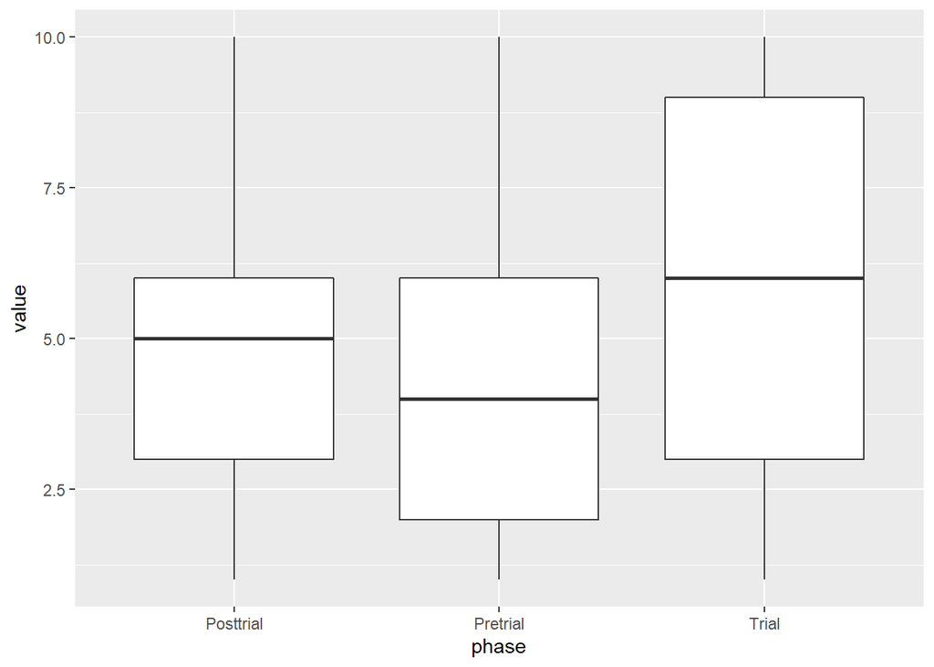

```r
ggplot(data = my_data, aes(x = phase, y = value)) +
  geom_boxplot()
```

What if we overlay the raw values?

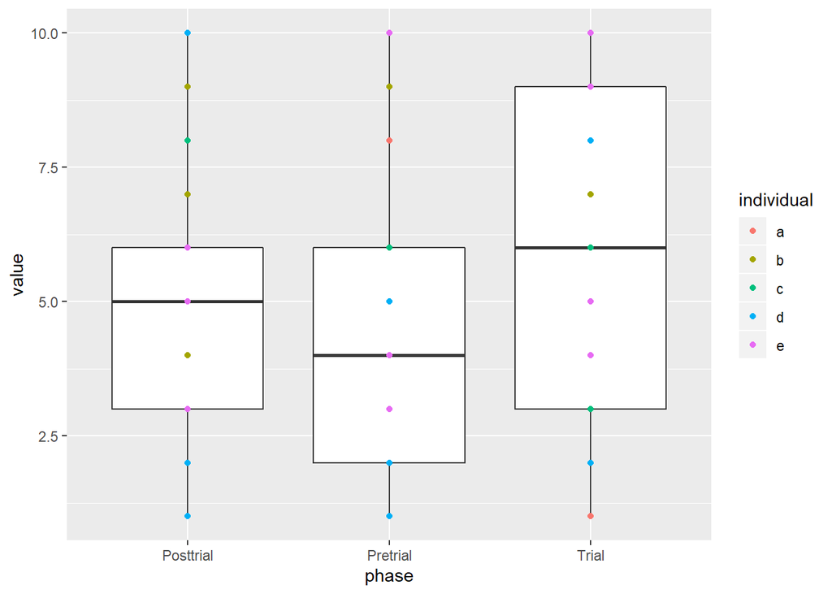

```r
ggplot(data = my_data, aes(x = phase, y = value)) +
  geom_boxplot() +
  geom_point(aes(color = individual))
```

```r
my_data <- my_data %>%
  mutate(nudge = (((time - time.start) * (1/3 - (-1/3))) /
                    (time.end - time.start)) - 1/3)

my_data
```

```
## # A tibble: 75 x 7
##    phase    time.start   time.end individual       time value  nudge
##    <chr>         <dbl>      <dbl> <chr>           <dbl> <int>  <dbl>
##  1 Pretrial 1580731200 1580731440 a          1580731200     2 -0.333
##  2 Pretrial 1580731200 1580731440 a          1580731260     6 -0.167
##  3 Pretrial 1580731200 1580731440 a          1580731320     1  0
##  4 Pretrial 1580731200 1580731440 a          1580731380     8  0.167
##  5 Pretrial 1580731200 1580731440 a          1580731440     8  0.333
##  6 Trial    1580731500 1580731740 a          1580731500     9 -0.333
##  7 Trial    1580731500 1580731740 a          1580731560     1 -0.167
##  8 Trial    1580731500 1580731740 a          1580731620     1  0
##  9 Trial    1580731500 1580731740 a          1580731680     7  0.167
## 10 Trial    1580731500 1580731740 a          1580731740     8  0.333
## # ... with 65 more rows
```

How do we “nudge” the values? In the `position` argument of `geom_point`, we can provide how much we want the values “nudged” using the `position_nudge` function in `ggplot`. Note that this function is not aware of what data you’re using, so you have to give the full reference using `$`.

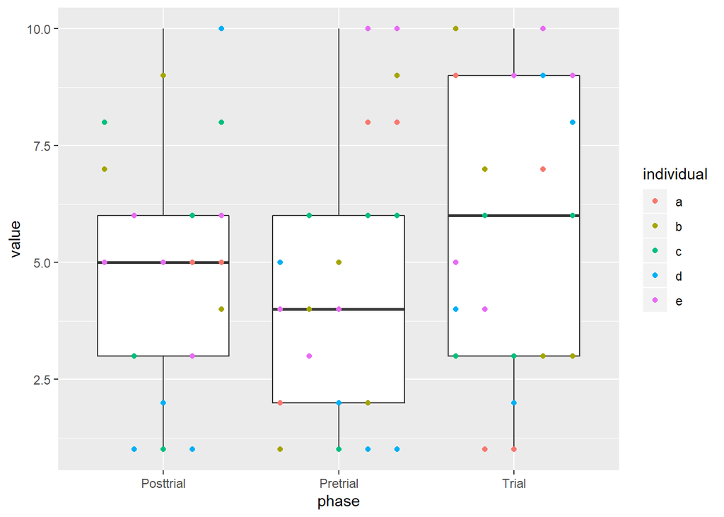

```r
ggplot(data = my_data, aes(x = phase, y = value)) +
  geom_boxplot() +
  geom_point(aes(color = individual),
             position = position_nudge(x = my_data$nudge))
```

The points are where they’re supposed to be, now we just have to connect them!

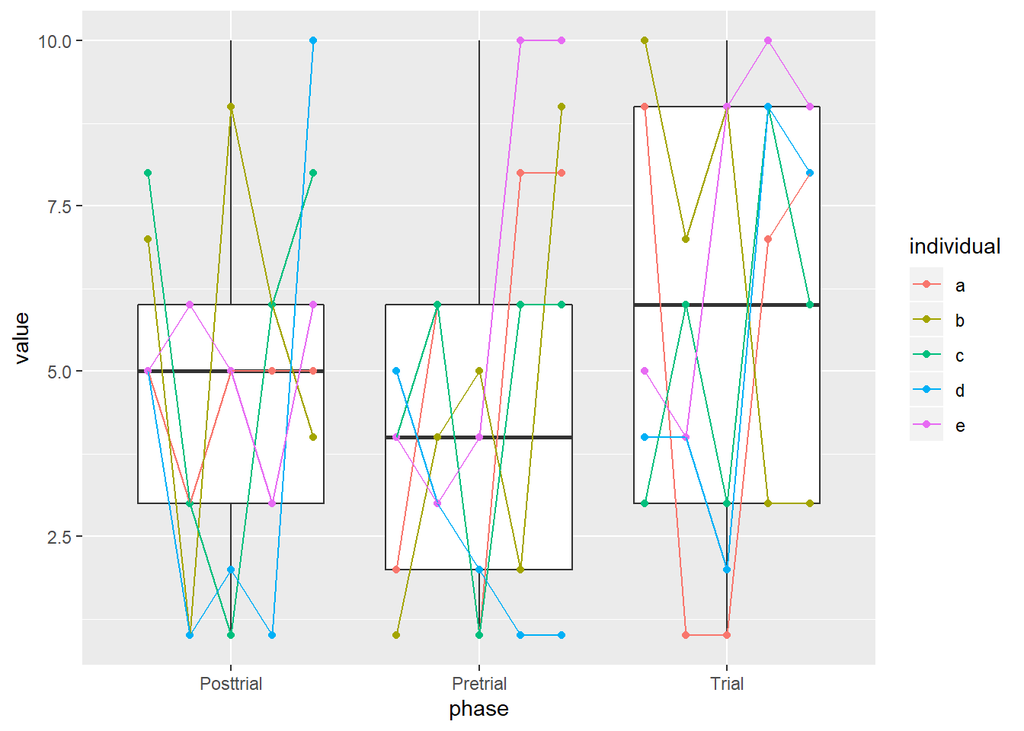

```r
ggplot(data = my_data, aes(x = phase, y = value)) +
  geom_boxplot() +
  geom_point(aes(color = individual),
             position = position_nudge(x = my_data$nudge)) +
  geom_line(aes(color = individual),
            position = position_nudge(x = my_data$nudge))
```